# R Notebook

Good Morning:

This is your daily COVID-19 report, sent on Friday, September 11, 2020 at 3:00 PM (EDT). Shown below is a current **draft** in continual development and error checking. Please feel free to reach out with suggestions or issues!

### USA overall

> As of yesterday, there has been a total of 6,416,847 cases of COVID-19 in the USA. This is a change of 37,876 (0.59%) new cases since the day prior. The 7 day moving average is currently 3.563e+04 new cases which is a -3% change since the day prior and -11.93% change since the week prior. The immediate trend is heading downward. Based on the addition of yesterday’s data, there was not a recent (within 3 days) inflection point (days since last inflection point: 11 –> 2020-08-30).

#### 7-day moving average of new cases in the US (2020-01-21 to 2020-09-10)

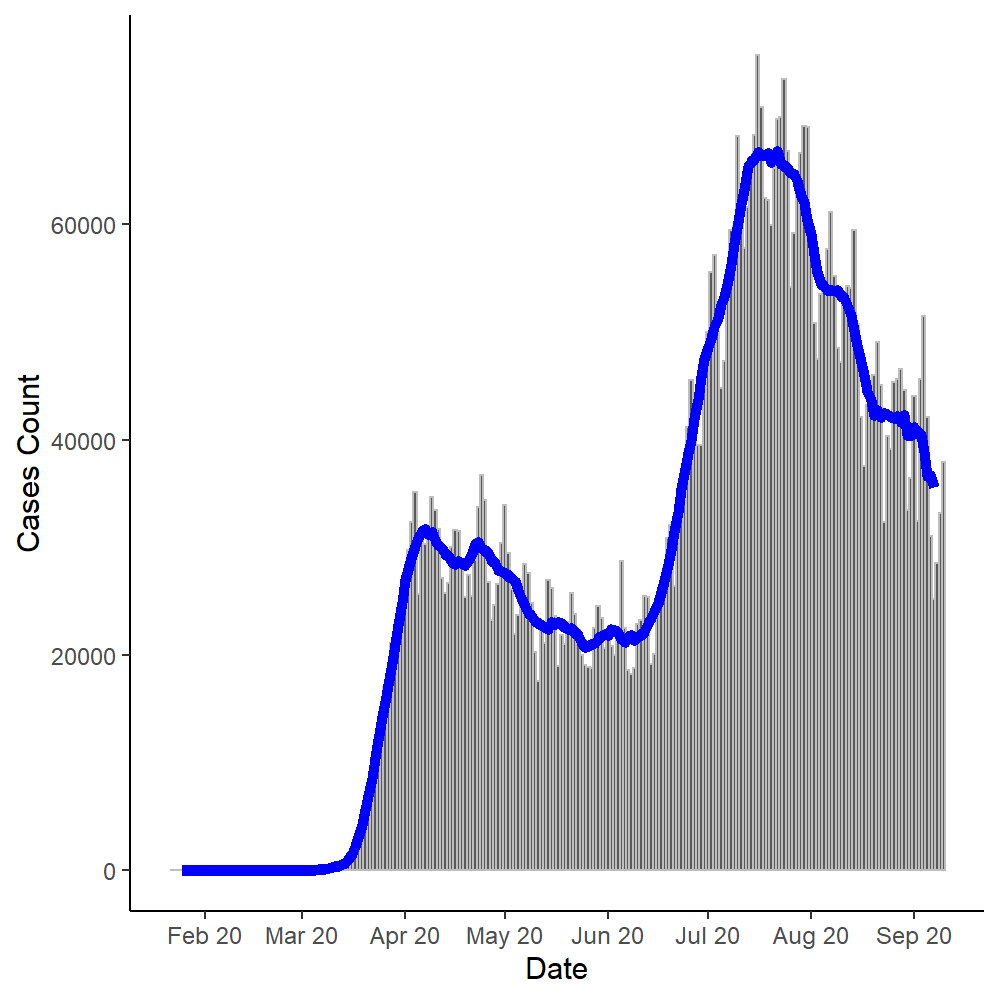

### Los Angeles County, CA

> As of yesterday, there has been a total of 251,024 cases of COVID-19 in Los Angeles County, CA. This is a change of 1,165 (0.47%) new cases since the day prior. The 7 day moving average is currently 860.7 new cases which is a 1.7% change since the day prior and -24.81% change since the week prior. The immediate trend is heading downward. Based on the addition of yesterday’s data, there was not a recent (within 3 days) inflection point (days since last inflection point: 31 –> 2020-08-10).

#### 7-day moving average of new cases in Los Angeles County (2020-01-26 to 2020-09-10)

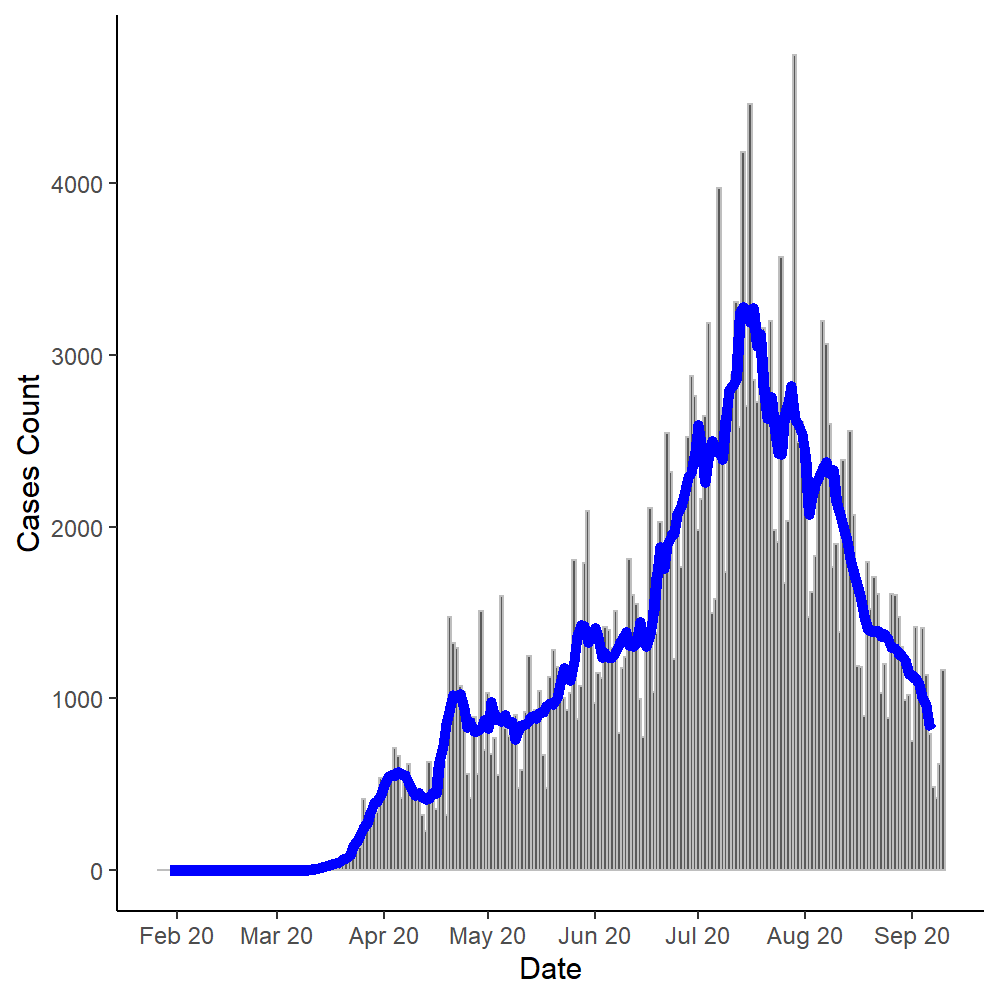

### New York City, NY

> As of yesterday, there has been a total of 241,686 cases of COVID-19 in New York City, NY. This is a change of 335 (0.14%) new cases since the day prior. The 7 day moving average is currently 267.3 new cases which is a 1.74% change since the day prior and -5.36% change since the week prior. The immediate trend is heading downward. Based on the addition of yesterday’s data, there was not a recent (within 3 days) inflection point (days since last inflection point: 5 –> 2020-09-05).

#### 7-day moving average of new cases in New York City (2020-03-01 to 2020-09-10)

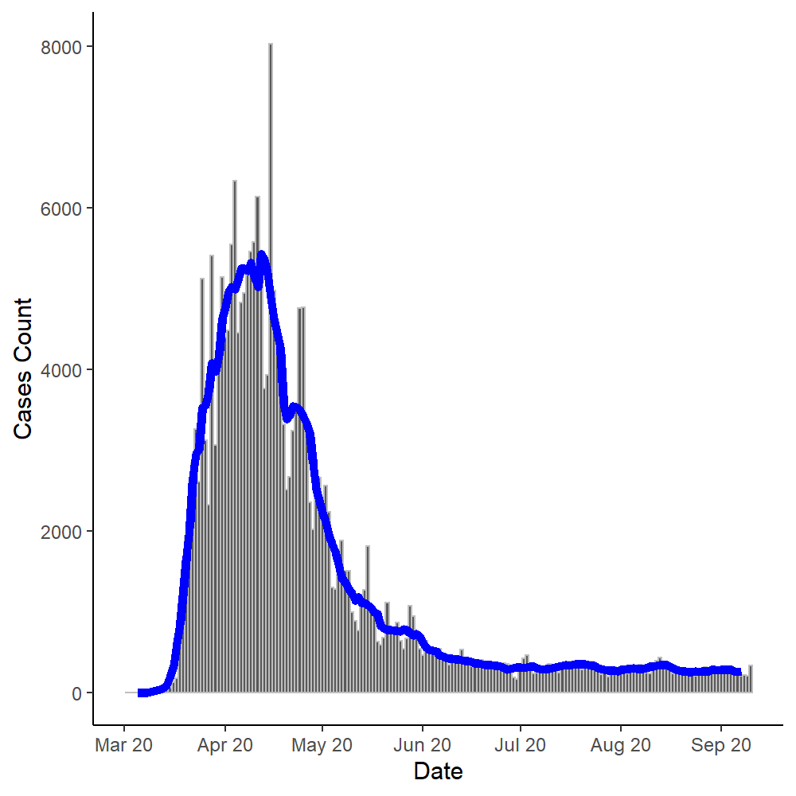

### Chicago (Cook County), IL

> As of yesterday, there has been a total of 132,966 cases of COVID-19 in Cook County, IL. This is a change of 565 (0.43%) new cases since the day prior. The 7 day moving average is currently 707.7 new cases which is a 3.53% change since the day prior and 14.65% change since the week prior. The immediate trend is heading upward. Based on the addition of yesterday’s data, there was not a recent (within 3 days) inflection point (days since last inflection point: 9 –> 2020-09-01).

#### 7-day moving average of new cases in Chicago (Cook County) (2020-01-24 to 2020-09-10)

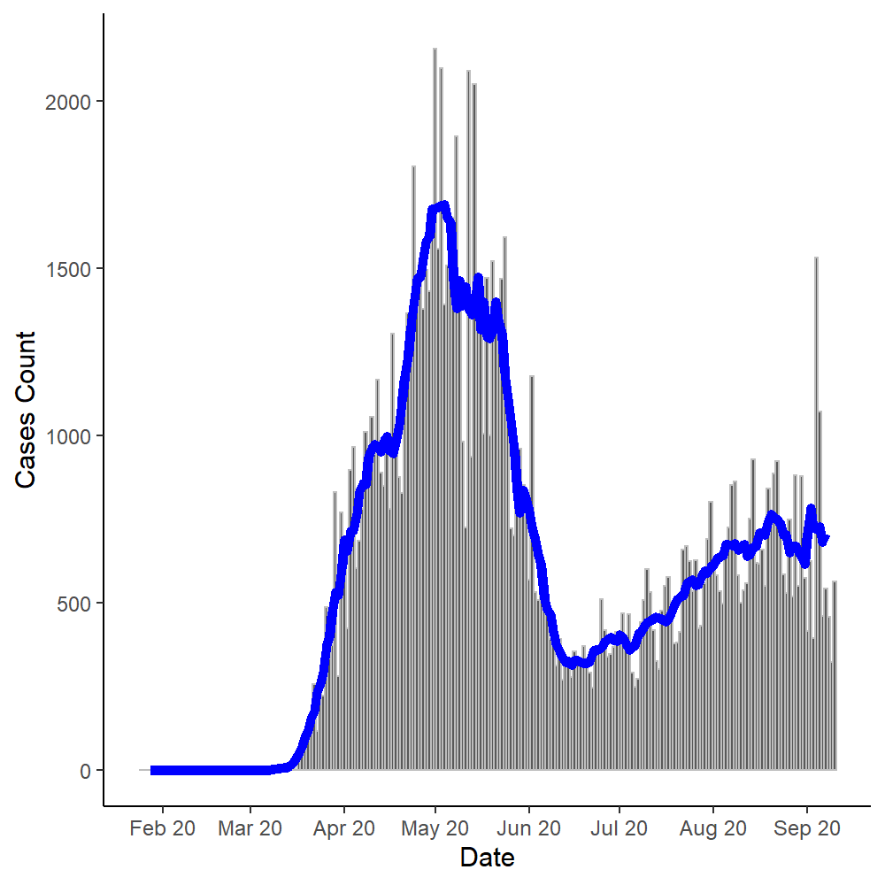

### Boston (Suffolk County), MA

#### 7-day moving average of new cases in Boston (Suffolk County) (2020-02-01 to 2020-09-10)

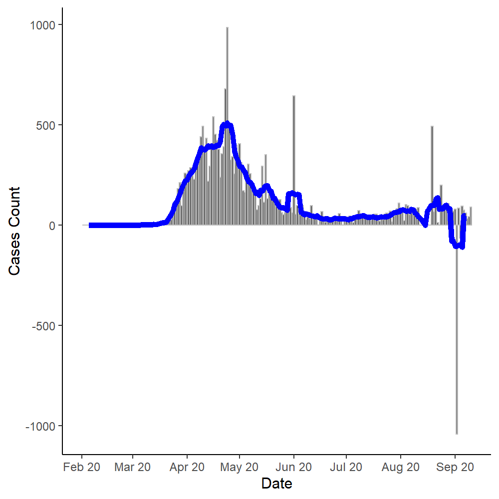

### Hong Kong

> As of yesterday, there has been a total of 4,913 cases of COVID-19 in Hong Kong. This is a change of 12 (0.24%) new cases since the day prior. The 7 day moving average is currently 10.71 new cases which is a 5.63% change since the day prior and -9.64% change since the week prior. The immediate trend is heading downward. Based on the addition of yesterday’s data, there was not a recent (within 3 days) inflection point (days since last inflection point: 41 –> 2020-07-31).

#### 7-day moving average of new cases in Hong Kong (2020-01-22 to 2020-09-10)

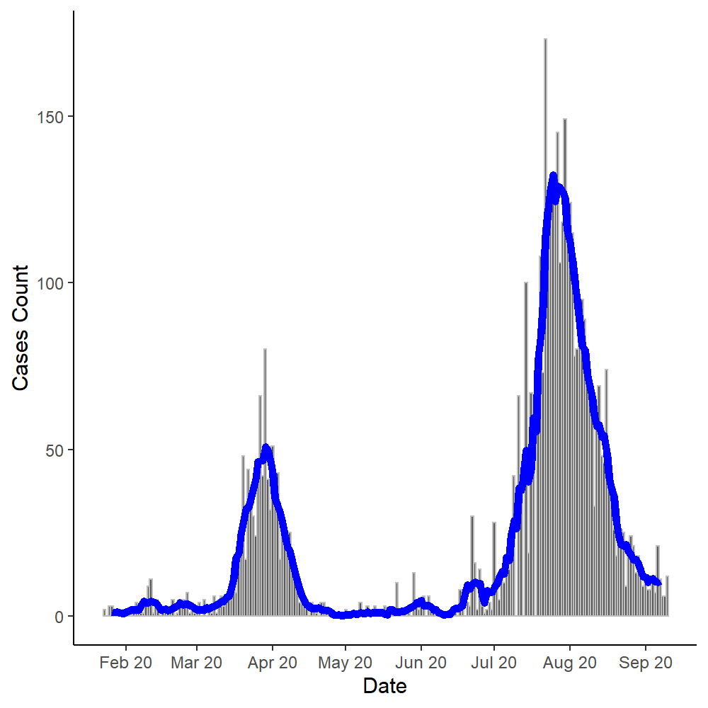